What's The Progress?

# Analysis on the Pros of Overwatch

In a lot of esports, players watch the professional players as they have both a high mechanical skill and a deep understanding of the game.

Feb 9, 2020 • 18 min read

# Table of Contents

```python
import pandas as pd
from IPython.core.display import display, HTML
display(HTML("<style>.container { width:100% !important; }</style>"))
```

# Loading the Data Frame

I used the pandas library to import my csv file to a Dataframe

```python
df = pd.read_csv("owl.csv")
df
```

|  | playerId | teamId | role | name | team | eliminations_avg_per_10m | deaths_avg_per_10m | hero_damage_avg_per_10m | healing_avg_per_10m | ultimates_earned_avg_per_10m | final_blows_avg_per_10m | time_played_total | count |
| --- | --- | --- | --- | --- | --- | --- | --- | --- | --- | --- | --- | --- | --- |
| 0 | 8675 | 7693 | offense | Adora | HZS | 16.002129 | 3.876235 | 5390.964430 | 5678.864360 | 4.410253 | 4.134037 | 65166.328327 | 1 |
| 1 | 3985 | 4523 | offense | aKm | DAL | 17.296143 | 5.178533 | 9600.623636 | 158.646056 | 4.575825 | 6.050875 | 75658.485169 | 1 |
| 2 | 8812 | 7692 | tank | ameng | CDH | 16.470544 | 6.202665 | 7051.640852 | 0.724798 | 4.511644 | 5.046006 | 88703.810417 | 1 |
| 3 | 4841 | 4403 | support | Anamo | NYE | 14.165021 | 2.745207 | 3948.127250 | 6563.244540 | 3.567532 | 1.898150 | 97041.863429 | 1 |
| 4 | 5715 | 4404 | offense | Architect | SFS | 18.181756 | 4.555888 | 7825.862117 | 3806.894747 | 4.639483 | 8.087747 | 28710.098079 | 1 |
| 5 | 4652 | 7697 | support | ArK | WAS | 7.870130 | 2.641469 | 2482.555936 | 6825.268613 | 3.518943 | 1.320735 | 66326.727702 | 1 |
| 6 | 5878 | 4402 | tank | Axxiom | BOS | 13.589015 | 6.323052 | 7227.732159 | 0.000000 | 3.771645 | 3.383387 | 10817.561445 | 1 |
| 7 | 4491 | 7698 | offense | babybay | ATL | 18.285137 | 4.898535 | 9724.894013 | 153.512705 | 4.520151 | 6.320031 | 58670.601443 | 1 |
| 8 | 8896 | 7692 | offense | Baconjack | CDH | 15.605830 | 6.119487 | 7305.171594 | 123.938222 | 4.231318 | 6.506221 | 26374.758866 | 1 |
| 9 | 4624 | 4525 | support | Bani | HOU | 11.303448 | 5.257418 | 4791.691330 | 6825.377770 | 3.680192 | 2.102967 | 2282.489336 | 1 |
| 10 | 8676 | 7693 | offense | Bazzi | HZS | 15.814585 | 5.846427 | 5369.937012 | 7506.352638 | 4.589445 | 3.800178 | 20525.356901 | 1 |
| 11 | 4655 | 4410 | support | Bdosin | LDN | 15.048464 | 4.107217 | 6983.868463 | 8836.736647 | 4.746420 | 3.882816 | 88234.919687 | 1 |
| 12 | 8731 | 7693 | support | BEBE | HZS | 14.154976 | 3.952661 | 7197.340358 | 9429.701829 | 4.803399 | 3.533836 | 91685.070527 | 1 |
| 13 | 8708 | 7694 | tank | BenBest | PAR | 13.411352 | 6.584489 | 6648.912608 | 0.000000 | 4.201147 | 4.026099 | 44559.264875 | 1 |
| 14 | 4643 | 4406 | support | BigG00se | GLA | 12.350082 | 4.683845 | 3870.859580 | 6429.321595 | 3.655210 | 2.206065 | 92744.320062 | 1 |
| 15 | 4639 | 7699 | tank | Bischu | GZC | 16.794393 | 5.927433 | 7229.213813 | 1836.443127 | 2.963716 | 8.891149 | 1214.691094 | 1 |
| 16 | 8184 | 4525 | offense | blase | HOU | 14.115152 | 5.688758 | 5288.563477 | 5127.842249 | 3.993433 | 4.545983 | 95556.889781 | 1 |
| 17 | 4625 | 4525 | support | Boink | HOU | 8.675604 | 5.084554 | 2736.000684 | 5754.139120 | 3.133041 | 1.772292 | 90391.403033 | 1 |
| 18 | 4079 | 4524 | support | Boombox | PHI | 14.716397 | 4.686374 | 6282.962865 | 9251.731158 | 4.765247 | 3.542715 | 91285.929199 | 1 |
| 19 | 8704 | 4407 | offense | bqb | FLA | 16.439333 | 4.809016 | 8641.233568 | 319.525665 | 4.536164 | 4.972728 | 87959.775570 | 1 |
| 20 | 8771 | 7696 | tank | BUMPER | VAN | 16.630474 | 5.906248 | 7969.093625 | 6.324790 | 4.654208 | 5.399093 | 113574.634219 | 1 |
| 21 | 10031 | 4407 | support | byrem | FLA | 11.418219 | 5.360666 | 5266.262933 | 7719.478526 | 3.752466 | 4.127713 | 11192.639166 | 1 |
| 22 | 4620 | 4524 | offense | carpe | PHI | 17.983018 | 4.844880 | 8782.867900 | 137.704463 | 4.146629 | 7.031507 | 97959.083057 | 1 |
| 23 | 8721 | 7699 | support | Chara | GZC | 10.361039 | 3.866669 | 3932.990917 | 5914.067038 | 3.253993 | 1.912912 | 88137.878443 | 1 |
| 24 | 5831 | 4404 | tank | Choihyobin | SFS | 19.391551 | 3.472553 | 6035.142896 | 302.338209 | 2.882165 | 5.957548 | 111790.956037 | 1 |
| 25 | 4663 | 4523 | support | Closer | DAL | 10.935586 | 3.527819 | 3511.197807 | 6354.660012 | 3.377837 | 1.936714 | 92011.533219 | 1 |
| 26 | 5306 | 4402 | offense | ColourHex | BOS | 14.899417 | 5.548090 | 8649.812908 | 168.870374 | 3.966816 | 5.752565 | 88030.291299 | 1 |
| 27 | 8892 | 4408 | support | CoMa | SHD | 7.909984 | 3.700223 | 2070.655671 | 6161.834635 | 3.184618 | 1.389100 | 98912.968913 | 1 |
| 28 | 4138 | 4525 | tank | coolmatt | HOU | 15.208515 | 4.527089 | 6774.211482 | 183.137562 | 4.214156 | 4.777435 | 28760.204940 | 1 |
| 29 | 8784 | 7697 | offense | Corey | WAS | 15.025158 | 5.201795 | 9003.292089 | 127.436107 | 4.608075 | 7.036929 | 88930.845029 | 1 |
| ... | ... | ... | ... | ... | ... | ... | ... | ... | ... | ... | ... | ... | ... |
| 123 | 9155 | 7693 | offense | SASIN | HZS | 15.217982 | 4.972212 | 6304.243753 | 450.467436 | 2.862789 | 6.026923 | 3982.131229 | 1 |
| 124 | 5442 | 4407 | offense | sayaplayer | FLA | 13.396877 | 5.487655 | 6048.630900 | 4204.440753 | 4.051289 | 6.067726 | 65164.442533 | 1 |
| 125 | 8728 | 7696 | offense | SeoMinSoo | VAN | 21.092578 | 3.588644 | 10933.062491 | 198.216055 | 5.075465 | 7.048881 | 88780.044028 | 1 |
| 126 | 10041 | 4405 | offense | Shax | VAL | 16.920446 | 5.694832 | 6499.728449 | 332.208914 | 4.148087 | 6.515075 | 25602.161674 | 1 |
| 127 | 4644 | 4406 | support | Shaz | GLA | 14.269397 | 4.063945 | 6467.514174 | 10113.314711 | 4.988753 | 3.243341 | 92127.225783 | 1 |
| 128 | 8725 | 7699 | support | shu | GZC | 14.059122 | 3.826302 | 6458.460594 | 8793.613298 | 4.767641 | 3.609592 | 88597.283044 | 1 |
| 129 | 4139 | 4404 | offense | sinatraa | SFS | 20.914314 | 3.497822 | 11849.397959 | 111.562321 | 5.252785 | 7.019851 | 99147.405428 | 1 |
| 130 | 8749 | 7696 | support | SLIME | VAN | 14.527621 | 3.703972 | 4165.190298 | 5882.757861 | 3.192704 | 2.724949 | 110314.003005 | 1 |
| 131 | 7831 | 4404 | tank | Smurf | SFS | 17.720797 | 4.922444 | 6587.333835 | 0.000000 | 3.999486 | 4.983974 | 19502.508479 | 1 |
| 132 | 4493 | 4524 | offense | snillo | PHI | 13.115663 | 7.286479 | 4268.438247 | 6369.452283 | 2.914592 | 2.914592 | 411.721471 | 1 |
| 133 | 3987 | 7694 | offense | SoOn | PAR | 17.156117 | 6.122379 | 8755.638934 | 181.999070 | 4.459629 | 6.852836 | 62426.713501 | 1 |
| 134 | 4637 | 4406 | tank | SPACE | GLA | 16.937870 | 3.754919 | 6297.654849 | 349.497358 | 4.028947 | 5.421303 | 81013.727587 | 1 |
| 135 | 4094 | 4525 | tank | SPREE | HOU | 16.057987 | 4.951975 | 7074.346063 | 442.661626 | 3.723781 | 5.265556 | 45921.072883 | 1 |
| 136 | 8747 | 7696 | offense | Stitch | VAN | 17.654422 | 5.264495 | 7419.042221 | 628.318125 | 4.211596 | 6.807114 | 24503.776509 | 1 |
| 137 | 8783 | 7697 | offense | Stratus | WAS | 15.851749 | 5.322345 | 6520.332819 | 1105.055288 | 3.785206 | 5.648987 | 31226.837463 | 1 |
| 138 | 4610 | 4404 | offense | STRIKER | SFS | 16.207208 | 6.053294 | 7380.909425 | 140.294067 | 4.491154 | 8.201238 | 6145.413898 | 1 |
| 139 | 4490 | 4404 | tank | super | SFS | 17.351664 | 5.256228 | 8277.983328 | 5.826254 | 4.657262 | 6.197460 | 98169.257876 | 1 |
| 140 | 4144 | 4406 | offense | Surefour | GLA | 16.264683 | 4.850343 | 7702.970198 | 2334.307256 | 4.409403 | 6.784467 | 59872.055648 | 1 |
| 141 | 3380 | 4523 | offense | Taimou | DAL | 13.643140 | 5.311080 | 6980.864470 | 353.580132 | 4.141668 | 6.724119 | 12313.880814 | 1 |
| 142 | 4104 | 4409 | support | tobi | SEO | 12.527639 | 3.561285 | 3821.983777 | 6536.903535 | 3.460255 | 2.083730 | 47510.945922 | 1 |
| 143 | 10021 | 4523 | tank | Trill | DAL | 11.016714 | 6.549455 | 5723.625044 | 0.000000 | 3.482947 | 3.369373 | 15848.646641 | 1 |
| 144 | 8729 | 7696 | support | Twilight | VAN | 16.044986 | 4.139107 | 7122.262343 | 9320.446421 | 5.048997 | 4.156948 | 100891.334471 | 1 |
| 145 | 3983 | 4523 | support | uNKOE | DAL | 12.889446 | 4.796602 | 5795.335146 | 9419.885852 | 4.592007 | 3.175002 | 79181.059063 | 1 |
| 146 | 8688 | 4404 | support | Viol2t | SFS | 17.185764 | 4.195764 | 7637.591409 | 10409.200261 | 5.300486 | 4.440653 | 110254.045210 | 1 |
| 147 | 5809 | 4406 | tank | Void | GLA | 19.343389 | 3.178936 | 6457.220391 | 250.965632 | 2.048810 | 5.555847 | 82291.682828 | 1 |
| 148 | 8710 | 7692 | offense | YangXiaoLong | CDH | 15.342481 | 5.957453 | 7572.263394 | 299.683611 | 4.115422 | 6.295547 | 51464.949743 | 1 |
| 149 | 8894 | 4408 | offense | YOUNGJIN | SHD | 17.674387 | 5.835630 | 6183.788216 | 5143.003544 | 4.046751 | 6.204125 | 89553.317851 | 1 |
| 150 | 8813 | 7692 | support | Yveltal | CDH | 7.512112 | 4.692623 | 2209.111332 | 7691.353637 | 3.602681 | 1.520697 | 91931.532277 | 1 |
| 151 | 8642 | 4523 | offense | ZachaREEE | DAL | 15.167823 | 5.666740 | 5698.414532 | 6211.639093 | 4.642945 | 3.866947 | 92010.565901 | 1 |
| 152 | 4098 | 4409 | tank | ZUNBA | SEO | 18.577579 | 2.959663 | 6789.544551 | 0.000000 | 2.549864 | 5.737194 | 13177.174514 | 1 |

153 rows × 13 columns

# Relations Between Stats

We are going to make a correlation table with the .corr() Function

```python
df_correleations = df[["eliminations_avg_per_10m","deaths_avg_per_10m","hero_damage_avg_per_10m","healing_avg_per_10m","ultimates_earned_avg_per_10m","final_blows_avg_per_10m","time_played_total"]]
df_corr_table = df_correleations.corr()
df_corr_table
```

|  | eliminations_avg_per_10m | deaths_avg_per_10m | hero_damage_avg_per_10m | healing_avg_per_10m | ultimates_earned_avg_per_10m | final_blows_avg_per_10m | time_played_total |
| --- | --- | --- | --- | --- | --- | --- | --- |
| eliminations_avg_per_10m | 1.000000 | -0.053546 | 0.702982 | -0.520182 | 0.108123 | 0.768385 | 0.184809 |
| deaths_avg_per_10m | -0.053546 | 1.000000 | 0.157248 | -0.242843 | 0.131407 | 0.183793 | -0.312624 |
| hero_damage_avg_per_10m | 0.702982 | 0.157248 | 1.000000 | -0.468124 | 0.467872 | 0.756272 | 0.130058 |
| healing_avg_per_10m | -0.520182 | -0.242843 | -0.468124 | 1.000000 | 0.345956 | -0.662879 | 0.021491 |
| ultimates_earned_avg_per_10m | 0.108123 | 0.131407 | 0.467872 | 0.345956 | 1.000000 | 0.100654 | 0.123582 |
| final_blows_avg_per_10m | 0.768385 | 0.183793 | 0.756272 | -0.662879 | 0.100654 | 1.000000 | 0.007640 |
| time_played_total | 0.184809 | -0.312624 | 0.130058 | 0.021491 | 0.123582 | 0.007640 | 1.000000 |

This is great, but let's filter out correlations below .5 because they aren't strong

```python
df_corr_table[(df_corr_table> .5) | (df_corr_table <-.5) & (df_corr_table < 1.0)]
```

|  | eliminations_avg_per_10m | deaths_avg_per_10m | hero_damage_avg_per_10m | healing_avg_per_10m | ultimates_earned_avg_per_10m | final_blows_avg_per_10m | time_played_total |
| --- | --- | --- | --- | --- | --- | --- | --- |
| eliminations_avg_per_10m | 1.000000 | NaN | 0.702982 | -0.520182 | NaN | 0.768385 | NaN |
| deaths_avg_per_10m | NaN | 1.0 | NaN | NaN | NaN | NaN | NaN |
| hero_damage_avg_per_10m | 0.702982 | NaN | 1.000000 | NaN | NaN | 0.756272 | NaN |
| healing_avg_per_10m | -0.520182 | NaN | NaN | 1.000000 | NaN | -0.662879 | NaN |
| ultimates_earned_avg_per_10m | NaN | NaN | NaN | NaN | 1.0 | NaN | NaN |
| final_blows_avg_per_10m | 0.768385 | NaN | 0.756272 | -0.662879 | NaN | 1.000000 | NaN |
| time_played_total | NaN | NaN | NaN | NaN | NaN | NaN | 1.0 |

this looks great, but we are going to make this cleaner with the .drop() function so that the table doesn't have so many NaNs

```python
df_column_drop = df_corr_table.drop(["deaths_avg_per_10m", "ultimates_earned_avg_per_10m", "time_played_total"])
df_relevant_correlations = df_column_drop.drop(["deaths_avg_per_10m", "ultimates_earned_avg_per_10m", "time_played_total"],axis=1)
df_relevant_correlations
```

|  | eliminations_avg_per_10m | hero_damage_avg_per_10m | healing_avg_per_10m | final_blows_avg_per_10m |
| --- | --- | --- | --- | --- |
| eliminations_avg_per_10m | 1.000000 | 0.702982 | -0.520182 | 0.768385 |
| hero_damage_avg_per_10m | 0.702982 | 1.000000 | -0.468124 | 0.756272 |
| healing_avg_per_10m | -0.520182 | -0.468124 | 1.000000 | -0.662879 |
| final_blows_avg_per_10m | 0.768385 | 0.756272 | -0.662879 | 1.000000 |

it appears that

> Eliminations and Hero Damage have a strong positive correlation with each other

> Eliminations and Final blows have a strong positive correlation with each other

> Eliminations and Healing have a moderate negative correlation with each other

> Final blows and Hero damage have a strong positive correlation with each other

> Final blows and Healing have a moderate negative correlation with each other

# Figuring Out Which Pro has The Best Stats

Let's take a look at which Pros have the most eliminations, damage dealt, final blows, ultimates earned, healing dealt, and least number of deaths

## Most Eliminations

```python
df_elims = df[["role", "name", "team", "eliminations_avg_per_10m"]]
df_elims.nlargest(10, "eliminations_avg_per_10m")
```

|  | role | name | team | eliminations_avg_per_10m |
| --- | --- | --- | --- | --- |
| 125 | offense | SeoMinSoo | VAN | 21.092578 |
| 129 | offense | sinatraa | SFS | 20.914314 |
| 75 | tank | JJANU | VAN | 20.056908 |
| 24 | tank | Choihyobin | SFS | 19.391551 |
| 98 | offense | Nenne | NYE | 19.365667 |
| 147 | tank | Void | GLA | 19.343389 |
| 59 | offense | Haksal | VAN | 19.341104 |
| 35 | offense | diem | SHD | 19.069305 |
| 93 | tank | Michelle | SEO | 18.928176 |
| 43 | offense | FITS | SEO | 18.882519 |

## Most Damage Dealt

```python
df_damage = df[["role", "name", "team", "hero_damage_avg_per_10m"]]
df_damage.nlargest(10, "hero_damage_avg_per_10m")
```

|  | role | name | team | hero_damage_avg_per_10m |
| --- | --- | --- | --- | --- |
| 129 | offense | sinatraa | SFS | 11849.397959 |
| 125 | offense | SeoMinSoo | VAN | 10933.062491 |
| 36 | offense | Diya | SHD | 10081.816984 |
| 69 | offense | ivy | TOR | 9899.923990 |
| 7 | offense | babybay | ATL | 9724.894013 |
| 56 | offense | GodsB | HZS | 9683.685510 |
| 1 | offense | aKm | DAL | 9600.623636 |
| 43 | offense | FITS | SEO | 9527.150428 |
| 98 | offense | Nenne | NYE | 9397.008782 |
| 116 | support | Ripa | GLA | 9261.831927 |

## Most Final Blows Dealt

```python
df_final_blows = df[["role", "name", "team", "final_blows_avg_per_10m"]]
df_final_blows.nlargest(10, "final_blows_avg_per_10m")
```

|  | role | name | team | final_blows_avg_per_10m |
| --- | --- | --- | --- | --- |
| 15 | tank | Bischu | GZC | 8.891149 |
| 87 | offense | Logix | TOR | 8.368265 |
| 138 | offense | STRIKER | SFS | 8.201238 |
| 4 | offense | Architect | SFS | 8.087747 |
| 35 | offense | diem | SHD | 7.917622 |
| 86 | offense | LiNkzr | HOU | 7.424964 |
| 45 | tank | fragi | GZC | 7.409291 |
| 36 | offense | Diya | SHD | 7.223194 |
| 99 | offense | nero | GZC | 7.065229 |
| 125 | offense | SeoMinSoo | VAN | 7.048881 |

## Most Ultimates Earned

```python
df_ultimates = df[["role", "name", "team", "ultimates_earned_avg_per_10m"]]
df_ultimates.nlargest(10, "ultimates_earned_avg_per_10m")
```

|  | role | name | team | ultimates_earned_avg_per_10m |
| --- | --- | --- | --- | --- |
| 116 | support | Ripa | GLA | 6.299542 |
| 110 | support | RAPEL | VAN | 5.533913 |
| 146 | support | Viol2t | SFS | 5.300486 |
| 129 | offense | sinatraa | SFS | 5.252785 |
| 78 | support | Krillin | LDN | 5.159678 |
| 111 | offense | Rascal | SFS | 5.150937 |
| 70 | support | IZaYaKI | SHD | 5.089731 |
| 125 | offense | SeoMinSoo | VAN | 5.075465 |
| 144 | support | Twilight | VAN | 5.048997 |
| 81 | offense | Krystal | HZS | 5.003493 |

## Most Healing Dealt

```python
df_heals = df[["role", "name", "team", "healing_avg_per_10m"]]
df_heals.nlargest(10, "healing_avg_per_10m")
```

|  | role | name | team | healing_avg_per_10m |
| --- | --- | --- | --- | --- |
| 116 | support | Ripa | GLA | 12489.082153 |
| 61 | support | HarryHook | DAL | 10731.194372 |
| 70 | support | IZaYaKI | SHD | 10720.448760 |
| 110 | support | RAPEL | VAN | 10575.563042 |
| 66 | support | HyP | PAR | 10568.360507 |
| 78 | support | Krillin | LDN | 10410.303999 |
| 146 | support | Viol2t | SFS | 10409.200261 |
| 127 | support | Shaz | GLA | 10113.314711 |
| 12 | support | BEBE | HZS | 9429.701829 |
| 145 | support | uNKOE | DAL | 9419.885852 |

## Least Deaths Recieved

```python
df_deaths = df[["role", "name", "team", "deaths_avg_per_10m"]]
df_deaths.nsmallest(10, "deaths_avg_per_10m")
```

|  | role | name | team | deaths_avg_per_10m |
| --- | --- | --- | --- | --- |
| 5 | support | ArK | WAS | 2.641469 |
| 3 | support | Anamo | NYE | 2.745207 |
| 152 | tank | ZUNBA | SEO | 2.959663 |
| 147 | tank | Void | GLA | 3.178936 |
| 93 | tank | Michelle | SEO | 3.239774 |
| 75 | tank | JJANU | VAN | 3.381134 |
| 24 | tank | Choihyobin | SFS | 3.472553 |
| 105 | support | Onlywish | GZC | 3.493403 |
| 129 | offense | sinatraa | SFS | 3.497822 |
| 25 | support | Closer | DAL | 3.527819 |

It wouldn't be fair to judge the stats for pro's who don't get a lot of play time.

let's see which pros got the most play time

## Most Playtime Recived

```python
df_time_largest = df[["role", "name", "team", "time_played_total"]]
df_time_largest.nlargest(10, "time_played_total")
```

|  | role | name | team | time_played_total |
| --- | --- | --- | --- | --- |
| 95 | support | moth | SFS | 116859.144868 |
| 20 | tank | BUMPER | VAN | 113574.634219 |
| 24 | tank | Choihyobin | SFS | 111790.956037 |
| 130 | support | SLIME | VAN | 110314.003005 |
| 146 | support | Viol2t | SFS | 110254.045210 |
| 59 | offense | Haksal | VAN | 109848.948995 |
| 75 | tank | JJANU | VAN | 107005.528668 |
| 111 | offense | Rascal | SFS | 102156.164167 |
| 144 | support | Twilight | VAN | 100891.334471 |
| 129 | offense | sinatraa | SFS | 99147.405428 |

## Least Playtime Recived

```python
df_time_smallest = df[["role", "name", "team", "time_played_total"]]
df_time_smallest.nsmallest(10, "time_played_total")
```

|  | role | name | team | time_played_total |
| --- | --- | --- | --- | --- |
| 132 | offense | snillo | PHI | 411.721471 |
| 77 | tank | Karayan | FLA | 496.426940 |
| 36 | offense | Diya | SHD | 498.394445 |
| 116 | support | Ripa | GLA | 666.715092 |
| 47 | support | FunnyAstro | ATL | 1020.976662 |
| 15 | tank | Bischu | GZC | 1214.691094 |
| 45 | tank | fragi | GZC | 1214.691094 |
| 53 | tank | Gator | ATL | 1735.402076 |
| 94 | tank | Mickie | DAL | 2149.076643 |
| 105 | support | Onlywish | GZC | 2232.780163 |

# Explanation For What I have chosen

I have choosen Eliminations, Damage, and Deaths for this project because I wanted to apply the findings to my own games.

Although these statistics do not reflect the skill level of a player, I personally would like to use these to figure out how I personally compare in my own competitive games to the pros.

# Grouping by role

Which roles has the best in the various categories

```python
df_group_role = df.groupby("role")
df_group_role = df_group_role.agg("sum").reset_index()
df_group_role
```

|  | role | playerId | teamId | eliminations_avg_per_10m | deaths_avg_per_10m | hero_damage_avg_per_10m | healing_avg_per_10m | ultimates_earned_avg_per_10m | final_blows_avg_per_10m | time_played_total | count |
| --- | --- | --- | --- | --- | --- | --- | --- | --- | --- | --- | --- |
| 0 | offense | 386317 | 334557 | 946.176006 | 291.759163 | 425826.207321 | 130963.348462 | 246.230313 | 341.229728 | 3.354968e+06 | 57 |
| 1 | support | 352231 | 289111 | 599.786627 | 214.251135 | 238364.322933 | 386289.038203 | 202.228107 | 135.218342 | 3.153147e+06 | 49 |
| 2 | tank | 316162 | 270656 | 768.694654 | 242.023534 | 307152.496101 | 9071.285277 | 167.693455 | 242.304149 | 2.905581e+06 | 47 |

```python
df_group_role.plot.bar(x = "role")
```

[output not shown]

## Counts For Each Role

```python
df_group_role[["role","count"]]
```

|  | role | count |
| --- | --- | --- |
| 0 | offense | 57 |
| 1 | support | 49 |
| 2 | tank | 47 |

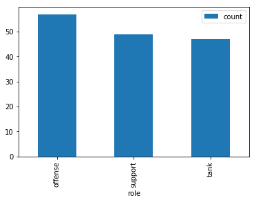

```python
df_group_role.plot.bar(x = "role", y = "count" )
```

across all the roles, the count seems to be pretty spread evenly

## How Many Eliminations Do Each Role Get?

They say that DPS should be the ones who get the most eliminations. That is true, however, tanks are pretty close to DPS.

```python
df_group_role["Overall Average Eliminations Per 10m"] = df_group_role["eliminations_avg_per_10m"]/df_group_role["count"]
df_group_role_elimminations = df_group_role[["role","Overall Average Eliminations Per 10m"]]
df_group_role_elimminations.nlargest(3, "Overall Average Eliminations Per 10m")
```

|  | role | Overall Average Eliminations Per 10m |
| --- | --- | --- |
| 0 | offense | 16.599579 |
| 2 | tank | 16.355205 |
| 1 | support | 12.240543 |

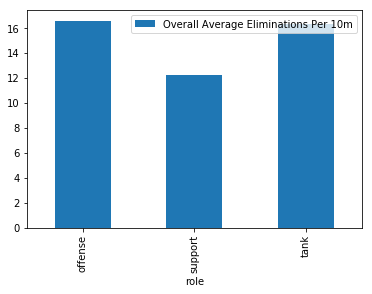

```python
df_group_role.plot.bar(x = "role", y = "Overall Average Eliminations Per 10m" )
```

It is also possible that during the GOATs meta (3 tanks 3 supports) tanks were the primary damage dealers.

## How Much Damage is Dealt by Each Role?

```python
df_group_role["Overall Average Damage Dealt per 10m"] = df_group_role["hero_damage_avg_per_10m"]/df_group_role["count"]
df_group_role_Damage = df_group_role[["role","Overall Average Damage Dealt per 10m"]]
df_group_role_Damage.nlargest(3, "Overall Average Damage Dealt per 10m")
```

|  | role | Overall Average Damage Dealt per 10m |
| --- | --- | --- |
| 0 | offense | 7470.635216 |
| 2 | tank | 6535.159492 |
| 1 | support | 4864.578019 |

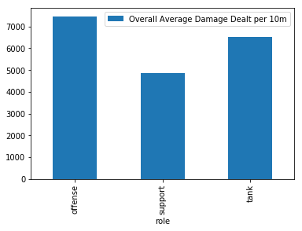

```python
df_group_role.plot.bar(x = "role", y = "Overall Average Damage Dealt per 10m" )
```

In this category, the DPS did 1000 more damage per 10 min compared to the tanks.

It is possible that the dps can focus more on dealing damage thus they would have more than the tanks. If we compare this back to the eliminations, it would appear that the DPS do the majority of the damage, and the tanks would finish off low health oppponents

## How Many Deaths Do Each Role Get?

```python
df_group_role["Overall Average Deaths Per 10m"] = df_group_role["deaths_avg_per_10m"]/df_group_role["count"]
df_group_role_Deaths = df_group_role[["role","Overall Average Deaths Per 10m"]]
df_group_role_Deaths.nlargest(3,"Overall Average Deaths Per 10m")
```

|  | role | Overall Average Deaths Per 10m |
| --- | --- | --- |
| 2 | tank | 5.149437 |
| 0 | offense | 5.118582 |
| 1 | support | 4.372472 |

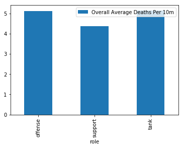

```python
df_group_role.plot.bar(x = "role", y = "Overall Average Deaths Per 10m" )
```

In terms of deaths, it appears that the dps and tanks die more than the supports.

The values are reasonable as supports in this game have better abilities that help them self sustain(Lucio amp and wall riding, Brigitte having a shield and inspire, Ana having sleep and nade, Moria healing orb and fade out etc.

DPS and tanks constantly need to put themselves in risky positions to get value and their abilities for the most part don't heal or sustain themselves (with obvious exceptions like soldier health pad, doomfist shields, and tracer recall).

# How do teams affect statistics

```python
df_group_team = df.groupby("team")
df_group_team = df_group_team.agg("sum").reset_index()
df_group_team
```

|  | team | playerId | teamId | eliminations_avg_per_10m | deaths_avg_per_10m | hero_damage_avg_per_10m | healing_avg_per_10m | ultimates_earned_avg_per_10m | final_blows_avg_per_10m | time_played_total | count |
| --- | --- | --- | --- | --- | --- | --- | --- | --- | --- | --- | --- |
| 0 | ATL | 85503 | 76980 | 157.793977 | 50.490675 | 62229.534763 | 29717.316325 | 39.633521 | 46.196669 | 542129.691046 | 10 |
| 1 | BOS | 19387 | 13206 | 41.831810 | 18.307436 | 22339.040042 | 168.870374 | 11.459645 | 13.611692 | 191882.761582 | 3 |
| 2 | CDH | 88084 | 76920 | 140.685496 | 54.735281 | 65018.505578 | 26011.366858 | 40.810739 | 46.357993 | 559672.649090 | 10 |
| 3 | DAL | 52627 | 45230 | 134.600049 | 53.890802 | 57832.731141 | 35178.978760 | 38.816079 | 41.888466 | 552438.204392 | 10 |
| 4 | FLA | 57758 | 30849 | 101.959246 | 36.758415 | 39591.619961 | 19430.429026 | 24.740010 | 28.107798 | 354423.819966 | 7 |
| 5 | GLA | 40743 | 30842 | 108.744030 | 30.418445 | 49108.905545 | 32116.483102 | 29.843228 | 32.485101 | 489485.111905 | 7 |
| 6 | GZC | 79962 | 84689 | 159.908158 | 48.163967 | 60829.784838 | 35702.505750 | 40.969978 | 55.463993 | 521269.576366 | 11 |
| 7 | HOU | 52327 | 49775 | 156.571056 | 57.913864 | 65358.076043 | 40454.474520 | 44.219426 | 48.886158 | 691999.044075 | 11 |
| 8 | HZS | 96271 | 84623 | 165.066886 | 51.045510 | 69069.351907 | 45746.309547 | 44.340600 | 48.711405 | 593674.115148 | 11 |
| 9 | LDN | 37085 | 26460 | 90.434697 | 26.671602 | 36982.082658 | 26613.463389 | 25.221463 | 24.639127 | 387766.475242 | 6 |
| 10 | NYE | 30576 | 26418 | 99.575626 | 24.138331 | 38255.470540 | 22063.733172 | 25.311343 | 29.345523 | 503951.861376 | 6 |
| 11 | PAR | 47618 | 46164 | 83.029907 | 33.794198 | 36440.938464 | 32370.046951 | 26.240437 | 24.154430 | 350082.354087 | 6 |
| 12 | PHI | 22529 | 22620 | 78.232372 | 27.090128 | 31924.133892 | 15973.523240 | 19.257253 | 23.235296 | 385046.356130 | 5 |
| 13 | SEO | 69111 | 44090 | 159.211885 | 42.290420 | 63252.547481 | 36999.399026 | 38.336938 | 44.785125 | 520537.701585 | 10 |
| 14 | SFS | 51678 | 39636 | 156.843551 | 40.146791 | 65342.859290 | 29724.106798 | 39.777856 | 52.126540 | 692734.994042 | 9 |
| 15 | SHD | 69402 | 44080 | 155.626680 | 49.550898 | 68986.768585 | 30876.841884 | 39.830569 | 53.093820 | 687468.766518 | 10 |
| 16 | TOR | 29461 | 38475 | 72.679144 | 27.565865 | 34029.883995 | 17312.415607 | 20.488759 | 25.676763 | 245498.218567 | 5 |
| 17 | VAL | 19483 | 13215 | 42.786018 | 15.343999 | 18309.481229 | 7423.094689 | 11.850342 | 14.706421 | 184116.543925 | 3 |
| 18 | VAN | 74664 | 69264 | 154.987665 | 40.865496 | 61391.476594 | 34382.552916 | 38.925150 | 46.432199 | 681441.973097 | 9 |
| 19 | WAS | 30441 | 30788 | 54.089034 | 18.851711 | 25049.833807 | 8057.760008 | 16.078539 | 18.847698 | 278076.144761 | 4 |

```python
df_group_team[["team","count"]]
```

|  | team | count |
| --- | --- | --- |
| 0 | ATL | 10 |
| 1 | BOS | 3 |
| 2 | CDH | 10 |
| 3 | DAL | 10 |
| 4 | FLA | 7 |
| 5 | GLA | 7 |
| 6 | GZC | 11 |
| 7 | HOU | 11 |
| 8 | HZS | 11 |
| 9 | LDN | 6 |
| 10 | NYE | 6 |
| 11 | PAR | 6 |
| 12 | PHI | 5 |
| 13 | SEO | 10 |
| 14 | SFS | 9 |
| 15 | SHD | 10 |
| 16 | TOR | 5 |
| 17 | VAL | 3 |
| 18 | VAN | 9 |
| 19 | WAS | 4 |

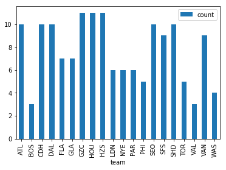

```python
df_group_team.plot.bar(x = "team", y = "count" )
```

```python
q1 = df_group_team["count"].quantile(.25)
q3 = df_group_team["count"].quantile(.75)
iqr = q3 - q1
lower_bound = q1 -(1.5 * iqr)
upper_bound = q3 +(1.5 * iqr)
print({"Quartile 1": q1})
print({"Quartile 3":q3})
print({"IQR": iqr })
print({"Lower Bound" : lower_bound})
print({"Upper Bound" : upper_bound})
```

```
{'Quartile 1': 5.75}
{'Quartile 3': 10.0}
{'IQR': 4.25}
{'Lower Bound': -0.625}
{'Upper Bound': 16.375}
```

Although our teams don't have any outliers by the IQR, we probably should exclude the the Boston Uprising, LA Valliant, and Washington Justice as they don't have enough for a team

## How Many Eliminations Do Each Team Get?

Let's find out which teams had the most eliminations per 10 minutes

```python
df_group_team["Overall Average Eliminations Per 10m"] = df_group_team["eliminations_avg_per_10m"]/df_group_team["count"]
df_team_largest_elim = df_group_team[["team","Overall Average Eliminations Per 10m"]]
df_team_largest_elim.nlargest(20,"Overall Average Eliminations Per 10m")
```

|  | team | Overall Average Eliminations Per 10m |
| --- | --- | --- |
| 14 | SFS | 17.427061 |
| 18 | VAN | 17.220852 |
| 10 | NYE | 16.595938 |
| 13 | SEO | 15.921189 |
| 0 | ATL | 15.779398 |
| 12 | PHI | 15.646474 |
| 15 | SHD | 15.562668 |
| 5 | GLA | 15.534861 |
| 9 | LDN | 15.072450 |
| 8 | HZS | 15.006081 |
| 4 | FLA | 14.565607 |
| 6 | GZC | 14.537105 |
| 16 | TOR | 14.535829 |
| 17 | VAL | 14.262006 |
| 7 | HOU | 14.233732 |
| 2 | CDH | 14.068550 |
| 1 | BOS | 13.943937 |
| 11 | PAR | 13.838318 |
| 19 | WAS | 13.522258 |
| 3 | DAL | 13.460005 |

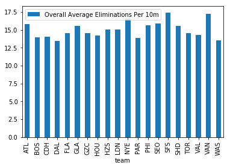

```python
df_group_team.plot.bar(x = "team", y = "Overall Average Eliminations Per 10m" )
```

This looks pretty messy, let's calculate for any outliers

```python
q1 = df_group_team["Overall Average Eliminations Per 10m"].quantile(.25)
q3 = df_group_team["Overall Average Eliminations Per 10m"].quantile(.75)
iqr = q3 - q1
lower_bound = q1 -(1.5 * iqr)
upper_bound = q3 +(1.5 * iqr)
print({"Quartile 1": q1})
print({"Quartile 3":q3})
print({"IQR": iqr })
print({"Lower Bound" : lower_bound})
print({"Upper Bound" : upper_bound})
```

```
{'Quartile 1': 14.192436660434511}
{'Quartile 3': 15.679705219204635}
{'IQR': 1.4872685587701238}
{'Lower Bound': 11.961533822279325}
{'Upper Bound': 17.91060805735982}
```

## How Much Damage is Dealt by Each Team?

```python
df_group_team["Overall Average Damage Dealt per 10m"] = df_group_team["hero_damage_avg_per_10m"]/df_group_team["count"]
df_team_largest_damage = df_group_team[["team","Overall Average Damage Dealt per 10m"]]
df_team_largest_damage.nlargest(20,"Overall Average Damage Dealt per 10m")
```

|  | team | Overall Average Damage Dealt per 10m |
| --- | --- | --- |
| 1 | BOS | 7446.346681 |
| 14 | SFS | 7260.317699 |
| 5 | GLA | 7015.557935 |
| 15 | SHD | 6898.676859 |
| 18 | VAN | 6821.275177 |
| 16 | TOR | 6805.976799 |
| 2 | CDH | 6501.850558 |
| 12 | PHI | 6384.826778 |
| 10 | NYE | 6375.911757 |
| 13 | SEO | 6325.254748 |
| 8 | HZS | 6279.031992 |
| 19 | WAS | 6262.458452 |
| 0 | ATL | 6222.953476 |
| 9 | LDN | 6163.680443 |
| 17 | VAL | 6103.160410 |
| 11 | PAR | 6073.489744 |
| 7 | HOU | 5941.643277 |
| 3 | DAL | 5783.273114 |
| 4 | FLA | 5655.945709 |
| 6 | GZC | 5529.980440 |

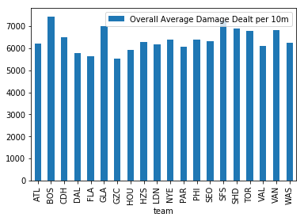

```python
df_team_largest_damage.plot.bar(x = "team", y = "Overall Average Damage Dealt per 10m" )
```

Surpisingly enough, Boston seems to have a higher damage dealt dispite having less players. This is odd because it wasn't an issue for eliminations.

## How Many Deaths is Recieved By Each Team?

```python
df_group_team["Overall Average Deaths Per 10m"] = df_group_team["deaths_avg_per_10m"]/df_group_team["count"]
df_team_smallest_death = df_group_team[["team","Overall Average Deaths Per 10m"]]
df_team_smallest_death.nsmallest(20,"Overall Average Deaths Per 10m")
```

|  | team | Overall Average Deaths Per 10m |
| --- | --- | --- |
| 10 | NYE | 4.023055 |
| 13 | SEO | 4.229042 |
| 5 | GLA | 4.345492 |
| 6 | GZC | 4.378542 |
| 9 | LDN | 4.445267 |
| 14 | SFS | 4.460755 |
| 18 | VAN | 4.540611 |
| 8 | HZS | 4.640501 |
| 19 | WAS | 4.712928 |
| 15 | SHD | 4.955090 |
| 0 | ATL | 5.049067 |
| 17 | VAL | 5.114666 |
| 4 | FLA | 5.251202 |
| 7 | HOU | 5.264897 |
| 3 | DAL | 5.389080 |
| 12 | PHI | 5.418026 |
| 2 | CDH | 5.473528 |
| 16 | TOR | 5.513173 |
| 11 | PAR | 5.632366 |
| 1 | BOS | 6.102479 |

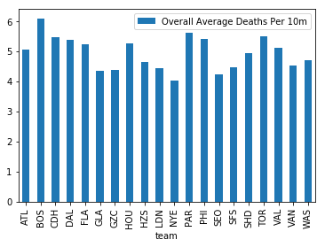

```python
df_team_smallest_death.plot.bar(x = "team", y = "Overall Average Deaths Per 10m" )
```

# Linear Regression?

```python
from sklearn.linear_model import LinearRegression
```

```python
model = LinearRegression()
model = model.fit(df[["eliminations_avg_per_10m","deaths_avg_per_10m","hero_damage_avg_per_10m", "healing_avg_per_10m"]], df["ultimates_earned_avg_per_10m"])
```